# Reproducible Research Project: Technical and Humanities Students’ Perspectives on the Development and Sustainability of Artificial Intelligence (AI)

Szymon Karkoszka, Antoni Piotrowski

1. Why it is important to reproduce the paper — problem description and topic importance

The perception of students on AI in education is a crucial topic to analyze from an economic standpoint. The incorporation of AI in the education sector has been increasing in recent years, with the emergence of smart classrooms and personalized learning platforms. The potential benefits of AI in education include improved learning outcomes, increased accessibility, and efficiency gains in educational delivery. Understanding the perceptions of students towards AI in education is vital to inform policies and investment decisions in the education sector. The analysis of student perceptions can provide insights into the potential barriers and facilitators to AI adoption in education, as well as inform strategies for the development of AI technologies that are sensitive to student needs and concerns.

This paper aims to analyze students’ perception on the AI in Education. Therfore we decide to examine the differences between the studies.

Loading required packages

```r
library(rstudioapi)
library(tidyverse)
library(RColorBrewer)
library(reshape2)
```

```r
library(ggplot2)
library(kableExtra)
library(scales)
```

2. Data In terms of the comparison, the data we found are excellent as they both compare student and both from Romania. Unfortunately, our data set is *10 times smaller* but much more informative. Our data are also much more up to date and we can say that we compare data between two “AI Waves” — one from 2017 and another from 2022.

The dataset utilized in this study encompasses the responses obtained from a survey administered to undergraduate students in their 2nd and 3rd years of study at the Faculty of Cybernetics, Statistics, and Economic Informatics. The survey was conducted online and disseminated through social media groups. Its objective was to acquire insights into students’ perceptions regarding the role of artificial intelligence (AI) in the domain of education.

Loading the data

```r
current_path <- rstudioapi::getActiveDocumentContext()$path
current_path <- path.expand(current_path)
current_path <- dirname(current_path)
to_csv <- file.path(current_path, "Data", "Survey_AI.csv")
to_csv
```

```
## [1] "/Users/komputer/Desktop/RR_git1/Project/RR_Final_Projeckt/Data/Survey_AI.csv"
```

```r
data <- read.csv(to_csv)
```

Checking the structure of the data

```r
str(data)
```

```
## 'data.frame':    91 obs. of  35 variables:
##  $ ID                                  : int  1 2 3 4 5 6 7 8 9 10 ...
##  $ Q1.AI_knowledge                     : int  8 7 5 5 4 5 7 6 6 4 ...
##  $ Q2.AI_sources                       : chr  "Internet;Books/Scientific papers (physical/online format)" "Internet;Social media" "Internet;Books/Scientific papers (physical/online format)" "Internet;Social media" ...
##  $ Q2.1.Internet                       : int  1 1 1 1 1 1 0 1 1 1 ...
##  $ Q2.2.Books.Papers                   : int  1 0 1 0 0 0 1 0 1 0 ...
##  $ Q2.3.Social_media                   : int  0 1 0 1 0 0 1 0 0 0 ...
##  $ Q2.4.Discussions                    : int  0 0 0 0 0 1 1 0 1 0 ...
##  $ Q2.5.NotInformed                    : int  0 0 0 0 0 0 0 0 0 0 ...
##  $ Q3.1.AI_dehumanization              : int  1 2 2 4 1 3 1 1 2 4 ...
##  $ Q3.2.Job_replacement                : int  2 3 1 4 2 4 2 1 4 4 ...
##  $ Q3.3.Problem_solving                : int  5 4 4 5 5 4 4 5 5 4 ...
##  $ Q3.4.AI_rulling_society             : int  1 1 1 3 1 3 1 1 2 3 ...
##  $ Q4.1.AI_costly                      : int  4 3 3 4 3 4 5 3 5 4 ...
##  $ Q4.2.Economic_crisis                : int  2 3 1 3 1 3 4 2 2 3 ...
```

[output cut: 21 more lines]

Deleting character variables (they’re only as comments for the variables for Q2.1-Q2.5 and Q6.1-Q6.7)

```r
data <- subset(data, select = -c(Q2.AI_sources, Q6.Domains, ID))
```

Changing all variables to numeric

```r
data <- mutate_all(data, as.numeric)
```

Checking for missing values

```r
print(missing_values <- colSums(is.na(data)))
```

```
##                      Q1.AI_knowledge                        Q2.1.Internet
##                                    0                                    0
##                    Q2.2.Books.Papers                    Q2.3.Social_media
##                                    0                                    0
##                     Q2.4.Discussions                     Q2.5.NotInformed
##                                    0                                    0
##               Q3.1.AI_dehumanization                 Q3.2.Job_replacement
##                                    0                                    0
##                 Q3.3.Problem_solving              Q3.4.AI_rulling_society
##                                    0                                    0
##                       Q4.1.AI_costly                 Q4.2.Economic_crisis
##                                    0                                    0
##                 Q4.3.Economic_growth                        Q4.4.Job_loss
##                                    0                                    0
##                          Q5.Feelings                       Q6.1.Education
##                                    0                                    0
##                        Q6.2.Medicine                     Q6.3.Agriculture
##                                    0                                    0
##                   Q6.4.Constructions                       Q6.5.Marketing
##                                    0                                    0
##                  Q6.6.Administration                             Q6.7.Art
##                                    0                                    0
##                     Q7.Utility_grade                Q8.Advantage_teaching
##                                    0                                    0
##                Q9.Advantage_learning             Q10.Advantage_evaluation
##                                    0                                    0
## Q11.Disadvantage_educational_process                           Q12.Gender
##                                    0                                    0
##                    Q13.Year_of_study                            Q14.Major
##                                    0                                    0
##                     Q15.Passed_exams                              Q16.GPA
##                                    0                                    0
```

Creating data frame with sources of students’ knowledge with their counts and producing an appropriate plot

Comparison with the paper: A first perspective they identify how well the respondents understood the concept of artificial intelligence. Their results show that 84.6% consider that they know what artificial intelligence means, whereas 12% claim that they do not know what the concept means. At the same time, 3.4% answered “I don’t know/I won’t answer”

The highest percentage belongs to the category of those who believe that they have an average awareness of artificial intelligence (36.1%). By referring to this average category, while cumulating two other answers (very well informed, 2.4%, and well informed, 16.8%), which represent the number of those with an above-average level of awareness, as well as cumulating the remaining two answers (poorly informed, 35%, and very poorly informed, 9.7%) which represent the category of those with a below-average level of awareness, showing that the number of those who consider themselves less informed is greater than the category of those who believe that they are well informed on the subject (44.7% as opposed to 19.2%).

No missing values found, so we can proceed with the barplot of students’ knowledge

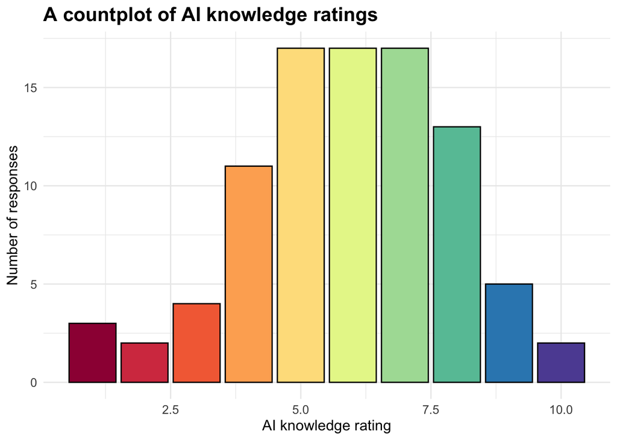

```r
custom_colors <- brewer.pal(10, "Spectral")

fig1 <- ggplot(data, aes(x = Q1.AI_knowledge)) +
  geom_bar(aes(fill = factor(Q1.AI_knowledge)), color = "black") +
  scale_fill_manual(values = custom_colors) +
  xlab("AI knowledge rating") +
  ylab("Number of responses") +
  ggtitle("A countplot of AI knowledge ratings") +
  theme_minimal() +
  theme(plot.title = element_text(size = 16, face = "bold"),
        axis.title = element_text(size = 12),
        axis.text = element_text(size = 10),
        legend.title = element_blank(),
        legend.position = "none")

print(fig1)
```

```r
source_names <- c("Internet", "Books/Papers", "Social Media", "Discussions", "Not Informed")
source_counts <- sapply(data[, c("Q2.1.Internet", "Q2.2.Books.Papers", "Q2.3.Social_media", "Q2.4.Discussions", "Q2.5.NotInformed")], function(col) sum(col == 1))

source_data <- data.frame(Source = source_names, Count = source_counts)

source_data$Proportion <- source_data$Count / sum(source_data$Count)
```

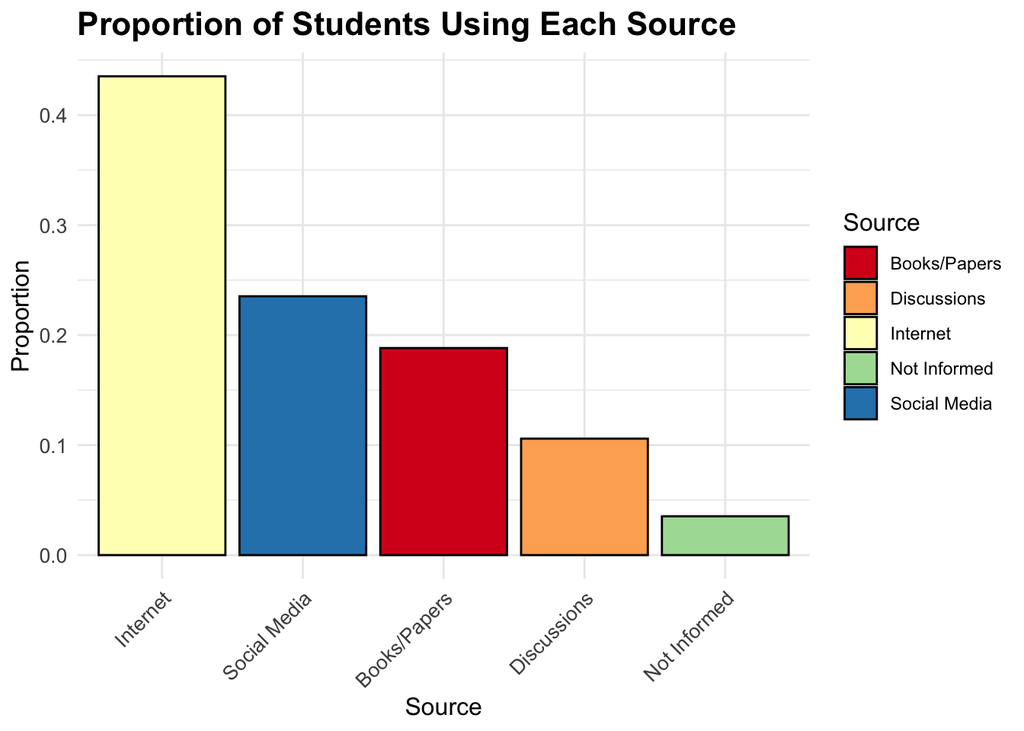

```r
custom_colors <- brewer.pal(5, "Spectral")
fig2 <- ggplot(source_data, aes(x = reorder(Source, -Proportion), y = Proportion, fill = Source)) +
  geom_bar(stat = "identity", color = "black") +
  labs(x = "Source", y = "Proportion", fill = "Source") +
  ggtitle("Proportion of Students Using Each Source") +
  theme_minimal() +
  theme(axis.text.x = element_text(angle = 45, hjust = 1),
        plot.title = element_text(size = 16, face = "bold"),
        axis.title = element_text(size = 12),
        axis.text = element_text(size = 10),
        legend.title = element_text(size = 12),
        legend.position = "right") +
  scale_fill_manual(values = custom_colors)

print(fig2)
```

########## correlations

# Select the relevant columns from the data frame

```r
selected_columns <- c("Q2.1.Internet", "Q2.2.Books.Papers", "Q2.3.Social_media", "Q2.4.Discussions", "Q2.5.NotInformed")
selected_data <- data[, selected_columns]
```

# Calculate the correlation matrix and round the values

```r
correlation_matrix <- round(cor(selected_data), 2)
correlation_data <- melt(correlation_matrix)

print(correlation_data)
```

```
##                 Var1              Var2 value
## 1      Q2.1.Internet     Q2.1.Internet  1.00
## 2  Q2.2.Books.Papers     Q2.1.Internet  0.00
## 3  Q2.3.Social_media     Q2.1.Internet  0.14
## 4   Q2.4.Discussions     Q2.1.Internet  0.10
## 5   Q2.5.NotInformed     Q2.1.Internet -0.55
## 6      Q2.1.Internet Q2.2.Books.Papers  0.00
## 7  Q2.2.Books.Papers Q2.2.Books.Papers  1.00
## 8  Q2.3.Social_media Q2.2.Books.Papers  0.04
## 9   Q2.4.Discussions Q2.2.Books.Papers  0.10
## 10  Q2.5.NotInformed Q2.2.Books.Papers -0.20
## 11     Q2.1.Internet Q2.3.Social_media  0.14
## 12 Q2.2.Books.Papers Q2.3.Social_media  0.04
## 13 Q2.3.Social_media Q2.3.Social_media  1.00
## 14  Q2.4.Discussions Q2.3.Social_media  0.28
## 15  Q2.5.NotInformed Q2.3.Social_media -0.24
## 16     Q2.1.Internet  Q2.4.Discussions  0.10
## 17 Q2.2.Books.Papers  Q2.4.Discussions  0.10
## 18 Q2.3.Social_media  Q2.4.Discussions  0.28
## 19  Q2.4.Discussions  Q2.4.Discussions  1.00
## 20  Q2.5.NotInformed  Q2.4.Discussions -0.13
## 21     Q2.1.Internet  Q2.5.NotInformed -0.55
## 22 Q2.2.Books.Papers  Q2.5.NotInformed -0.20
## 23 Q2.3.Social_media  Q2.5.NotInformed -0.24
## 24  Q2.4.Discussions  Q2.5.NotInformed -0.13
## 25  Q2.5.NotInformed  Q2.5.NotInformed  1.00
```

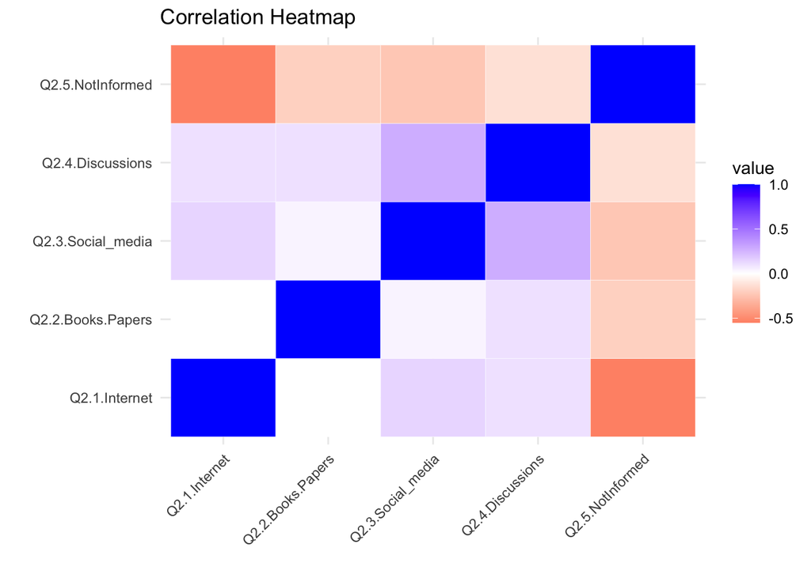

```r
ggplot(data = correlation_data, aes(x = Var1, y = Var2, fill = value)) +
  geom_tile(color = "white") +
  scale_fill_gradient2(low = "red", mid = "white", high = "blue", midpoint = 0) +
  theme_minimal() +
  labs(title = "Correlation Heatmap", x = "", y = "") +
  theme(axis.text.x = element_text(angle = 45, vjust = 1, hjust = 1))
```

Relation with student’s knowledge about AI

```r
# Define the columns vector
columns <- c("Q2.1.Internet", "Q2.2.Books.Papers", "Q2.3.Social_media", "Q2.4.Discussions", "Q2.5.NotInformed")

# Create an empty list to store the results
results <- list()

# Iterate over the columns
for (i in columns) {
  x1 <- mean(data[data[, i] == 0, "Q1.AI_knowledge"], na.rm = TRUE)
  x2 <- mean(data[data[, i] == 1, "Q1.AI_knowledge"], na.rm = TRUE)
  change <- round(x2 - x1, 2)
  results[[i]] <- c(x1, x2, change)
}

# Create a data frame from the results list
data2 <- data.frame(t(as.data.frame(results)))
colnames(data2) <- c("No - MeanQ1", "Yes - MeanQ1", "Absolute Change")
row.names(data2) <- columns

# Print the resulting data frame
print(data2)
```

```
##                   No - MeanQ1 Yes - MeanQ1 Absolute Change
## Q2.1.Internet        5.000000     6.121622            1.12
## Q2.2.Books.Papers    5.423729     6.812500            1.39
## Q2.3.Social_media    5.411765     6.550000            1.14
## Q2.4.Discussions     5.849315     6.166667            0.32
## Q2.5.NotInformed     6.129412     2.833333           -3.30
```

```r
# Define the column names and labels
columns <- c('Q3.1.AI_dehumanization', 'Q3.2.Job_replacement', 'Q3.3.Problem_solving', 'Q3.4.AI_rulling_society',
             'Q4.1.AI_costly', 'Q4.2.Economic_crisis', 'Q4.3.Economic_growth', 'Q4.4.Job_loss')
labels <- c('AI encourages dehumanization', 'Robots will replace people at work', 'AI helps to solve many problems in society',
            'AI will rule society', 'Machinery using AI is very expensive and resource-intensive to build and maintain',
            'AI will lead to a global economic crisis', 'AI will help global economic growth', 'AI leads to job losses')

# Subset the dataframe with the relevant columns
data_subset <- data[, columns]

str(data)
```

```
## 'data.frame':    91 obs. of  32 variables:
##  $ Q1.AI_knowledge                     : num  8 7 5 5 4 5 7 6 6 4 ...
##  $ Q2.1.Internet                       : num  1 1 1 1 1 1 0 1 1 1 ...
##  $ Q2.2.Books.Papers                   : num  1 0 1 0 0 0 1 0 1 0 ...
##  $ Q2.3.Social_media                   : num  0 1 0 1 0 0 1 0 0 0 ...
##  $ Q2.4.Discussions                    : num  0 0 0 0 0 1 1 0 1 0 ...
##  $ Q2.5.NotInformed                    : num  0 0 0 0 0 0 0 0 0 0 ...
##  $ Q3.1.AI_dehumanization              : num  1 2 2 4 1 3 1 1 2 4 ...
##  $ Q3.2.Job_replacement                : num  2 3 1 4 2 4 2 1 4 4 ...
##  $ Q3.3.Problem_solving                : num  5 4 4 5 5 4 4 5 5 4 ...
##  $ Q3.4.AI_rulling_society             : num  1 1 1 3 1 3 1 1 2 3 ...
##  $ Q4.1.AI_costly                      : num  4 3 3 4 3 4 5 3 5 4 ...
##  $ Q4.2.Economic_crisis                : num  2 3 1 3 1 3 4 2 2 3 ...
##  $ Q4.3.Economic_growth                : num  4 4 3 3 4 3 2 3 3 3 ...
##  $ Q4.4.Job_loss                       : num  2 3 2 4 2 4 4 2 4 4 ...
```

[output cut: 18 more lines]

```r
# Reshape the data for plotting
data_subset_long <- reshape2::melt(data_subset)
data_subset_long$variable <- factor(data_subset_long$variable, levels = columns, labels = labels)

str(data_subset_long )
```

```
## 'data.frame':    728 obs. of  2 variables:
##  $ variable: Factor w/ 8 levels "AI encourages dehumanization",..: 1 1 1 1 1 1 1 1 1 1 ...
##  $ value   : num  1 2 2 4 1 3 1 1 2 4 ...
```

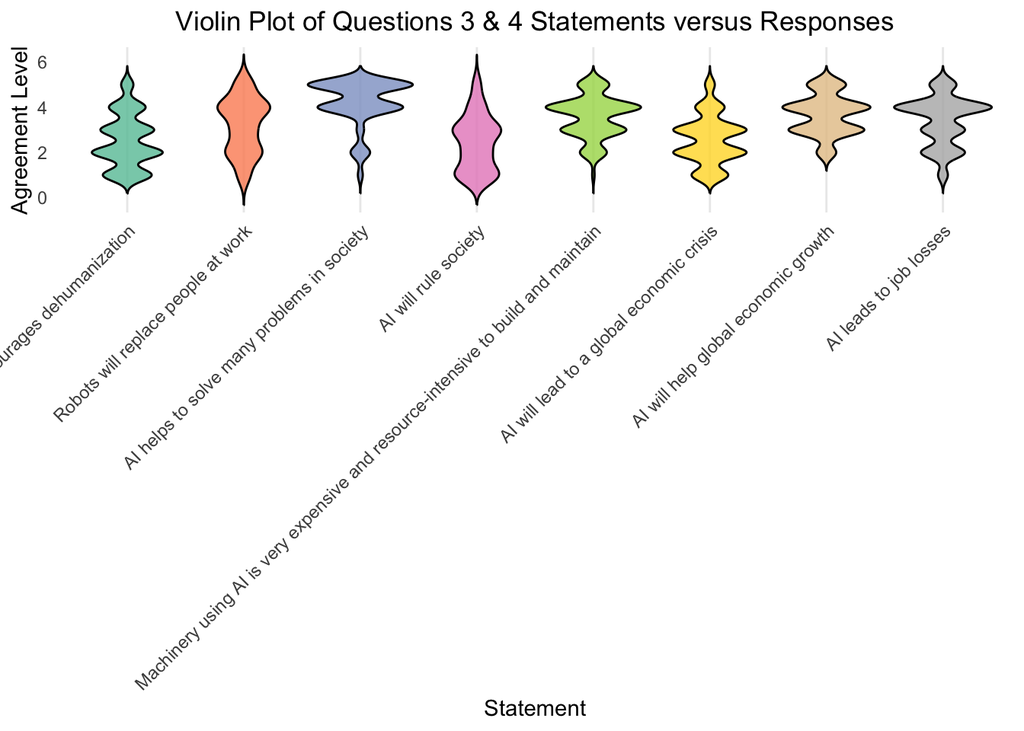

```r
my_palette <- brewer.pal(8, "Set2")
# Create a violin plot
ggplot(data_subset_long, aes(x = variable, y = value, fill = variable)) +
  geom_violin(color = "black", alpha = 0.8, scale = "count", trim = FALSE) +
  scale_fill_manual(values = my_palette) +
  labs(x = "Statement", y = "Agreement Level", fill = "") +
  ggtitle("Violin Plot of Questions 3 & 4 Statements versus Responses") +
  theme_minimal() +
  theme(axis.text.x = element_text(angle = 45, hjust = 1),
        plot.title = element_text(hjust = 0.5),
        legend.position = "none",
        panel.grid.major.y = element_blank(),
        panel.grid.minor = element_blank(),
        panel.border = element_blank())
```

```r
######### standard deviations in answers

# Calculate standard deviations
standard_deviations <- sapply(columns, function(column) {
  sd(data[[column]])
})

# Convert standard deviations to a data frame
sd_data <- data.frame(variable = names(standard_deviations),
                      sd = standard_deviations)

# Sort the data frame by standard deviation values
sd_data <- sd_data[order(sd_data$sd), ]

# Create a styled table
styled_table <- sd_data %>%
  kable(col.names = c("Variable", "Standard Deviation")) %>%
  kable_styling(full_width = FALSE, bootstrap_options = c("striped", "hover"))

styled_table
```

|  | Variable | Standard Deviation |
| --- | --- | --- |
| Q4.3.Economic_growth | Q4.3.Economic_growth | 0.8720319 |
| Q4.1.AI_costly | Q4.1.AI_costly | 0.9206623 |
| Q3.3.Problem_solving | Q3.3.Problem_solving | 1.0134625 |
| Q4.2.Economic_crisis | Q4.2.Economic_crisis | 1.0562911 |
| Q4.4.Job_loss | Q4.4.Job_loss | 1.0737175 |
| Q3.1.AI_dehumanization | Q3.1.AI_dehumanization | 1.1677389 |
| Q3.4.AI_rulling_society | Q3.4.AI_rulling_society | 1.2031704 |
| Q3.2.Job_replacement | Q3.2.Job_replacement | 1.2130749 |

```r
# Extract the desired values and labels from the dataframe
feelings <- c('Curiosity', 'Fear', 'Indifference', 'Trust')
# Adjust the indices accordingly
str(data$Q5.Feelings)
```

```
##  num [1:91] 1 1 1 1 1 2 1 1 1 1 ...
```

```r
print(data$Q5.Feelings)
```

```
##  [1] 1 1 1 1 1 2 1 1 1 1 1 1 4 1 3 3 3 2 1 1 1 3 1 1 1 1 1 1 1 1 1 1 1 1 1 3 1 1
## [39] 2 1 2 1 1 1 1 1 2 4 1 1 1 1 2 4 1 1 1 3 1 4 1 1 1 1 1 1 2 2 1 2 1 4 1 1 3 1
## [77] 1 1 3 3 1 2 1 3 1 2 1 1 4 2 4
```

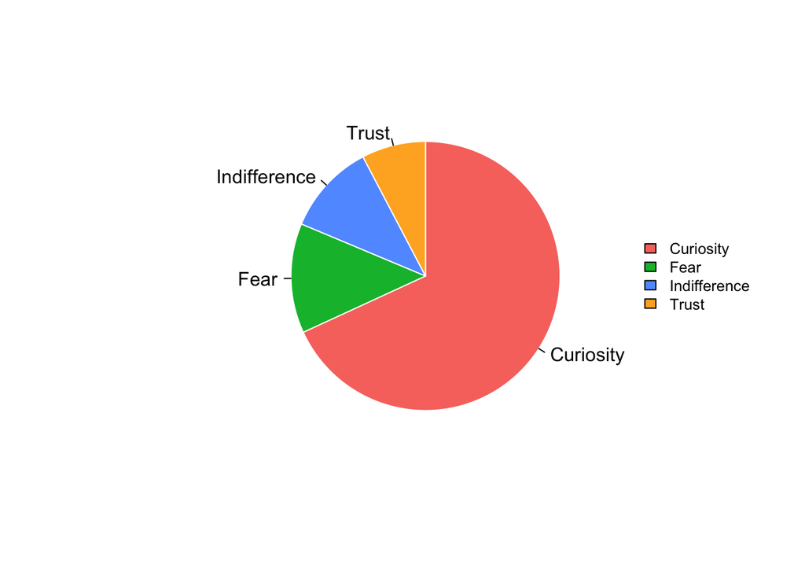

```r
counts <- table(data$Q5.Feelings)
# Define custom colors for the pie slices
custom_colors <- c('#F8766D', '#00BA38', '#619CFF', '#FFB028')

# Create the pie chart with enhanced appearance
pie(counts, labels = feelings, col = custom_colors, border = 'white',
    init.angle = 90, clockwise = TRUE)
legend("right", legend = feelings, fill = custom_colors,
       bty = "n", cex = 0.8)
```

```r
data3 <- data[c('Q1.AI_knowledge', 'Q3.2.Job_replacement', 'Q3.3.Problem_solving', 'Q3.4.AI_rulling_society', 'Q12.Gender')]

data3 <- data3 %>%
  mutate(Q1.AI_knowledge = case_when(
    Q1.AI_knowledge %in% c(1, 2) ~ "very poorly informed/uninformed",
    Q1.AI_knowledge %in% c(3, 4) ~ "poorly informed",
    Q1.AI_knowledge %in% c(5, 6) ~ "sufficiently informed",
    Q1.AI_knowledge %in% c(7, 8) ~ "well informed",
    Q1.AI_knowledge %in% c(9, 10) ~ "very well informed"
  ),
  Q12.Gender = case_when(
    Q12.Gender == 1 ~ 'F',
    Q12.Gender == 2 ~ 'M',
    TRUE ~ as.character(Q12.Gender)
  ),
  Q3.2.Job_replacement = case_when(
    Q3.2.Job_replacement %in% c(1) ~ "Strongly Disagree",
    Q3.2.Job_replacement %in% c(2) ~ "Partially Disagree",
    Q3.2.Job_replacement %in% c(3) ~ "Neutral",
    Q3.2.Job_replacement %in% c(4) ~ "Partially Agree",
    Q3.2.Job_replacement %in% c(5) ~ "Fully Agree"
  ),
  Q3.3.Problem_solving = case_when(
    Q3.3.Problem_solving %in% c(1) ~ "Strongly Disagree",
    Q3.3.Problem_solving %in% c(2) ~ "Partially Disagree",
    Q3.3.Problem_solving %in% c(3) ~ "Neutral",
    Q3.3.Problem_solving %in% c(4) ~ "Partially Agree",
    Q3.3.Problem_solving %in% c(5) ~ "Fully Agree"
  ),
  Q3.4.AI_rulling_society = case_when(
    Q3.4.AI_rulling_society %in% c(1) ~ "Strongly Disagree",
    Q3.4.AI_rulling_society %in% c(2) ~ "Partially Disagree",
    Q3.4.AI_rulling_society %in% c(3) ~ "Neutral",
    Q3.4.AI_rulling_society %in% c(4) ~ "Partially Agree",
    Q3.4.AI_rulling_society %in% c(5) ~ "Fully Agree"))
```

```r
data3 <- data3 %>%
  mutate(Q1.AI_knowledge = factor(Q1.AI_knowledge, levels = c("very poorly informed/uninformed", "poorly informed", "sufficiently informed", "well informed", "very well informed"), ordered = TRUE))

ordered_levels <- c("Strongly Disagree", "Partially Disagree", "Neutral", "Partially Agree", "Fully Agree")

data3 <- data3 %>%
  mutate(Q3.2.Job_replacement = factor(Q3.2.Job_replacement, levels = ordered_levels, ordered = TRUE))
data3 <- data3 %>%
  mutate(Q3.3.Problem_solving = factor(Q3.3.Problem_solving, levels = ordered_levels, ordered = TRUE))
data3 <- data3 %>%
  mutate(Q3.4.AI_rulling_society = factor(Q3.4.AI_rulling_society, levels = ordered_levels, ordered = TRUE))
```

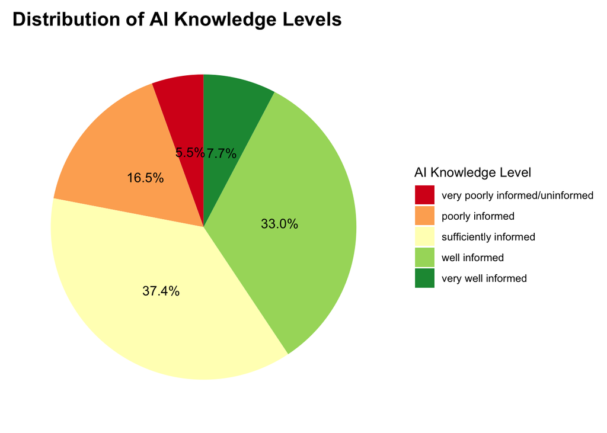

```r
knowledge_summary <- data3 %>%
  count(Q1.AI_knowledge) %>%
  rename(Category = Q1.AI_knowledge, Count = n) %>%
  mutate(Percentage = Count / sum(Count))

ggplot(knowledge_summary, aes(x = "", y = Percentage, fill = Category)) +
  geom_bar(stat = "identity", width = 1) +
  coord_polar(theta = "y") +
  labs(title = "Distribution of AI Knowledge Levels",
       x = NULL, y = NULL, fill = "AI Knowledge Level") +
  theme_minimal() +
  theme(axis.text.x = element_blank(),
        axis.ticks = element_blank(),
        panel.grid = element_blank(),
        plot.title = element_text(size = 16, face = "bold")) +
  scale_fill_brewer(palette = "RdYlGn") +
  geom_text(aes(label = percent(Percentage)), position = position_stack(vjust = 0.5))
```

```r
table_data <- data3 %>%
  group_by(Q12.Gender, Q1.AI_knowledge) %>%
  summarise(Count = n()) %>%
  mutate(Percentage = Count / sum(Count) * 100) %>%
  arrange(Q12.Gender, Q1.AI_knowledge)

pivot_table <- table_data %>%
  select(-Count) %>%
  pivot_wider(names_from = Q12.Gender, values_from = Percentage, values_fill = list(Percentage = 0))

pivot_table <- pivot_table %>%
  mutate(across(where(is.numeric), ~ paste0(round(.x, 1), "%")))

pivot_table %>%
  kable( format = "markdown", col.names = c("AI Knowledge Level", "Female (%)", "Male (%)")) %>%
  kable_styling(full_width = FALSE, bootstrap_options = c("striped", "hover"))
```

| AI Knowledge Level | Female (%) | Male (%) |
| --- | --- | --- |
| very poorly informed/uninformed | 1.7% | 12.5% |
| poorly informed | 18.6% | 12.5% |
| sufficiently informed | 42.4% | 28.1% |
| well informed | 32.2% | 34.4% |
| very well informed | 5.1% | 12.5% |

```r
table_data2 <- data3 %>%
  group_by(Q12.Gender, Q3.2.Job_replacement) %>%
  summarise(Count = n()) %>%
  mutate(Percentage = Count / sum(Count) * 100) %>%
  arrange(Q12.Gender, Q3.2.Job_replacement)

pivot_table2 <- table_data2 %>%
  select(-Count) %>%
  pivot_wider(names_from = Q12.Gender, values_from = Percentage, values_fill = list(Percentage = 0))

pivot_table2 <- pivot_table2 %>%
  mutate(across(where(is.numeric), ~ paste0(round(.x, 1), "%")))

pivot_table2 %>%
  kable( format = "markdown", col.names = c("Replacing the humans and jobs by gender", "Female (%)", "Male (%)")) %>%
  kable_styling(full_width = FALSE, bootstrap_options = c("striped", "hover"))
```

| Replacing the humans and jobs by gender | Female (%) | Male (%) |
| --- | --- | --- |
| Strongly Disagree | 6.8% | 12.5% |
| Partially Disagree | 27.1% | 21.9% |
| Neutral | 22% | 6.2% |
| Partially Agree | 39% | 31.2% |
| Fully Agree | 5.1% | 28.1% |

```r
table_data3 <- data3 %>%
  group_by(Q12.Gender, Q3.4.AI_rulling_society) %>%
  summarise(Count = n()) %>%
  mutate(Percentage = Count / sum(Count) * 100) %>%
  arrange(Q12.Gender, Q3.4.AI_rulling_society)

pivot_table3 <- table_data3 %>%
  select(-Count) %>%
  pivot_wider(names_from = Q12.Gender, values_from = Percentage, values_fill = list(Percentage = 0))

pivot_table3 <- pivot_table3 %>%
  mutate(across(where(is.numeric), ~ paste0(round(.x, 1), "%")))

pivot_table3 %>%
  kable( format = "markdown", col.names = c("AI will rull society/destroy humanity", "Female (%)", "Male (%)")) %>%
  kable_styling(full_width = FALSE, bootstrap_options = c("striped", "hover"))
```

| AI will rull society/destroy humanity | Female (%) | Male (%) |
| --- | --- | --- |
| Strongly Disagree | 30.5% | 31.2% |
| Partially Disagree | 22% | 12.5% |
| Neutral | 37.3% | 25% |
| Partially Agree | 8.5% | 18.8% |
| Fully Agree | 1.7% | 12.5% |

```r
table_data4 <- data3 %>%
  group_by(Q12.Gender, Q3.3.Problem_solving) %>%
  summarise(Count = n()) %>%
  mutate(Percentage = Count / sum(Count) * 100) %>%
  arrange(Q12.Gender, Q3.3.Problem_solving)

pivot_table4 <- table_data4 %>%
  select(-Count) %>%
  pivot_wider(names_from = Q12.Gender, values_from = Percentage, values_fill = list(Percentage = 0))

pivot_table4 <- pivot_table4 %>%
  mutate(across(where(is.numeric), ~ paste0(round(.x, 1), "%")))

pivot_table3 %>%
  kable( format = "markdown", col.names = c("AI helps to solve many problems in society", "Female (%)", "Male (%)")) %>%
  kable_styling(full_width = FALSE, bootstrap_options = c("striped", "hover"))
```

[output not shown]